# Tarea 06

Román Vélez Jiménez

# 1) Proportions

*Context:*

1. **Proporciones.** Usaremos datos de reincidencia en conducta criminal del estado de Iowa, este estado sigue a los delincuentes por un periodo de 3 años y registra el número de días hasta reincidencia para aquellos que son readmitidos en prisión. El departamento de correcciones utiliza los datos de reincidencia para evaluar sus programas de prevención de recaída en conducta criminal.

Los datos Recidivism contienen información de todos los delincuentes condenados por dos tipos de delito durante 2010 (*Recid* indica si recayeron en conducta criminal).

- De éstos $31.6\%$ reincidieron y volvieron a prisión. Utiliza simulación para aproximar la simulación muestral de $\hat{p}$, la proporción de delincuentes que reincidieron para muestras de tamaño 25.
- Calcula el error estándar de $\hat{p}$, y compáralo con el teórico $\sqrt{p(1-p)/n}$.
- Repite para muestras de tamaño 250 y compara.

## Read data

```r
library(tidyverse)
df_recidivism <- read_csv("../../data/Recidivism.csv")
print(head(df_recidivism))
```

```
## # A tibble: 6 × 8
##   Gender Age          Age25    Race              Offense Recid Type   Days
##   <chr>  <chr>        <chr>    <chr>             <chr>   <chr> <chr> <dbl>
## 1 M      Under 25     Under 25 White-NonHispanic Felony  Yes   Tech     16
## 2 M      55 and Older Over 25  White-NonHispanic Felony  Yes   Tech     19
## 3 M      25-34        Over 25  White-NonHispanic Felony  Yes   Tech     22
## 4 M      55 and Older Over 25  White-NonHispanic Felony  Yes   Tech     25
## 5 M      25-34        Over 25  Black-NonHispanic Felony  Yes   Tech     26
## 6 M      Under 25     Under 25 White-NonHispanic Felony  Yes   Tech     27
```

```r
print(glimpse(df_recidivism))
```

```
## Rows: 17,022
## Columns: 8
## $ Gender  <chr> "M", "M", "M", "M", "M", "M", "M", "M", "M", "M", "M", "M", "M…
## $ Age     <chr> "Under 25", "55 and Older", "25-34", "55 and Older", "25-34", …
## $ Age25   <chr> "Under 25", "Over 25", "Over 25", "Over 25", "Over 25", "Under…
## $ Race    <chr> "White-NonHispanic", "White-NonHispanic", "White-NonHispanic",…
## $ Offense <chr> "Felony", "Felony", "Felony", "Felony", "Felony", "Felony", "M…
## $ Recid   <chr> "Yes", "Yes", "Yes", "Yes", "Yes", "Yes", "Yes", "Yes", "Yes",…
## $ Type    <chr> "Tech", "Tech", "Tech", "Tech", "Tech", "Tech", "New", "Tech",…
## $ Days    <dbl> 16, 19, 22, 25, 26, 27, 28, 41, 44, 46, 48, 49, 49, 51, 51, 53…
## # A tibble: 17,022 × 8
##    Gender Age          Age25    Race              Offense     Recid Type   Days
##    <chr>  <chr>        <chr>    <chr>             <chr>       <chr> <chr> <dbl>
##  1 M      Under 25     Under 25 White-NonHispanic Felony      Yes   Tech     16
##  2 M      55 and Older Over 25  White-NonHispanic Felony      Yes   Tech     19
##  3 M      25-34        Over 25  White-NonHispanic Felony      Yes   Tech     22
##  4 M      55 and Older Over 25  White-NonHispanic Felony      Yes   Tech     25
##  5 M      25-34        Over 25  Black-NonHispanic Felony      Yes   Tech     26
##  6 M      Under 25     Under 25 White-NonHispanic Felony      Yes   Tech     27
##  7 M      45-54        Over 25  White-NonHispanic Misdemeanor Yes   New      28
##  8 M      45-54        Over 25  White-NonHispanic Felony      Yes   Tech     41
##  9 M      45-54        Over 25  White-NonHispanic Misdemeanor Yes   Tech     44
## 10 M      45-54        Over 25  White-NonHispanic Felony      Yes   Tech     46
## # … with 17,012 more rows
```

### Population mean & std

```r
# get exact proportion
prop_recid <- mean(df_recidivism$Recid == 'Yes', na.rm = TRUE)
print(str_glue("proportion of resid: {round(prop_recid * 100, 2)}%"))
```

```
## proportion of resid: 31.64%
```

```r
std_prop <- sqrt(prop_recid * (1 - prop_recid) * (nrow(df_recidivism))^(-1))
print(str_glue("std of prop of resid: {round(std_prop * 100, 8)}%"))
```

```
## std of prop of resid: 0.35646685%
```

### Boostrap

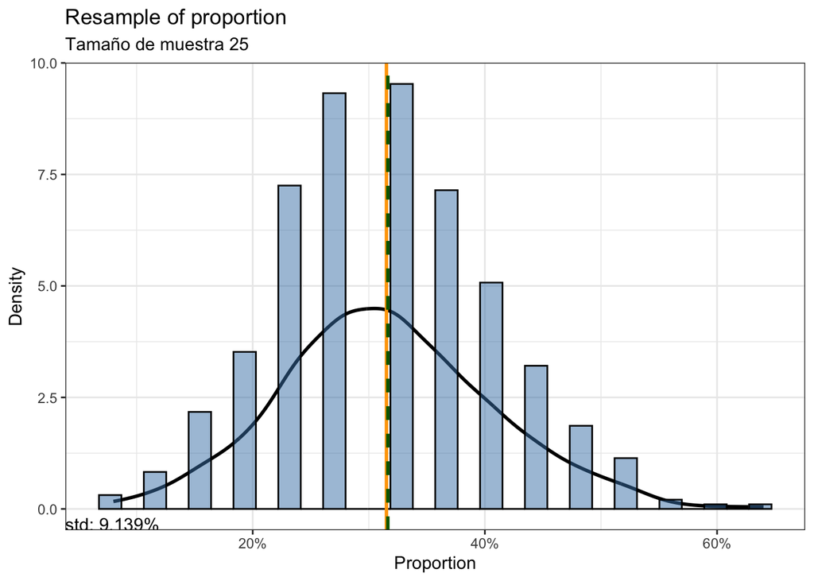

```r
# function
f_bootstrap_proportion <- function(df, M, B){
  # B: number of simulations
  # M: size of the sample
  #g: statistical function

  # generate B samples of indexes
  b_samples <- lapply(1:B, function(x) sample(df$Recid, size = M, replace = TRUE))

  # subset apply
  gsubset_apply <- function(x){
    return(mean(x == 'Yes'))
  }

  # # get B samples of the stat
  stats <- sapply(b_samples, gsubset_apply)
  return(stats)
}

# generate bootstrap
M <- 25
B <- 500
bootstrap_proportion <- f_bootstrap_proportion(
  df_recidivism,
  M = M,
  B = B
)

# plot histogram
df_plot <- tibble(
    simulations = 1:B,
    stats = bootstrap_proportion
  )
std_bootstrap <- sd(bootstrap_proportion)

df_plot |>
  ggplot(aes(stats)) +
  geom_density(size = 1) +
  geom_histogram(aes(y = ..density..), fill = "steelblue", alpha = 0.5, color = 'black') +
  geom_vline(xintercept = mean(df_plot$stats), color = 'orange', size = 1) +
  geom_vline(xintercept = prop_recid, color = 'darkgreen', size = 1, linetype = 2) +
  ggtitle("Resample of proportion", str_glue("Tamaño de muestra {M}")) +
  annotate("text", x=-Inf, y=-Inf, hjust=0, vjust=0, label=str_glue("std: {round(std_bootstrap * 100, 4)}%")) +
  xlab("Proportion") + ylab("Density") +
  scale_x_continuous(labels = scales::percent) +
  theme_bw()
```

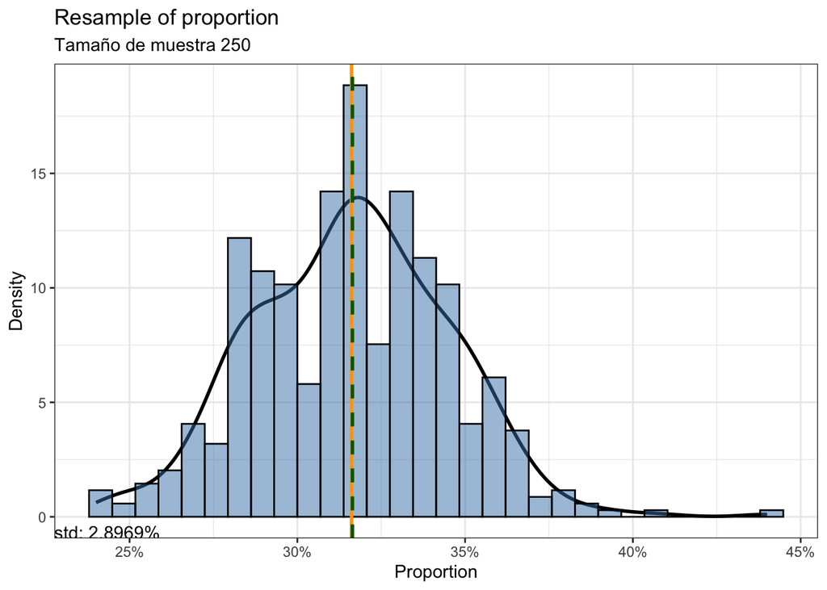

```r
# generate bootstrap
M <- 250
B <- 500
bootstrap_proportion <- f_bootstrap_proportion(
  df_recidivism,
  M = M,
  B = B
)

# plot histogram
df_plot <- tibble(
    simulations = 1:B,
    stats = bootstrap_proportion
  )
std_bootstrap <- sd(bootstrap_proportion)

df_plot |>
  ggplot(aes(stats)) +
  geom_density(size = 1) +
  geom_histogram(aes(y = ..density..), fill = "steelblue", alpha = 0.5, color = 'black') +
  geom_vline(xintercept = mean(df_plot$stats), color = 'orange', size = 1) +
  geom_vline(xintercept = prop_recid, color = 'darkgreen', size = 1, linetype = 2) +
  ggtitle("Resample of proportion", str_glue("Tamaño de muestra {M}")) +
  annotate("text", x=-Inf, y=-Inf, hjust=0, vjust=0, label=str_glue("std: {round(std_bootstrap * 100, 4)}%")) +
  xlab("Proportion") + ylab("Density") +
  scale_x_continuous(labels = scales::percent) +
  theme_bw()
```

*ANSWER:* We notice a bigger variance for the bootstrapped statistics, specially for small M. The theoretical std is too small by the fact of the number of observations.

# 2) Mixture of Distributions

2. **Mezcla de distribuciones**. Imaginemos que nuestro modelo teórico es una mezcla de dos poblaciones, una gamma y una normal

```r
muestrear_pob <- function(n){
  u <- runif(n) # número aleatorio
  map_dbl(u, ~ ifelse(.x < 1/2, rgamma(1, 5, 0.1), rnorm(1, 100, 5)))
}
```

El modelo teórico se puede graficar, pero también podemos obetener una aproximación buena haciendo una cantidad grande de simulaciones

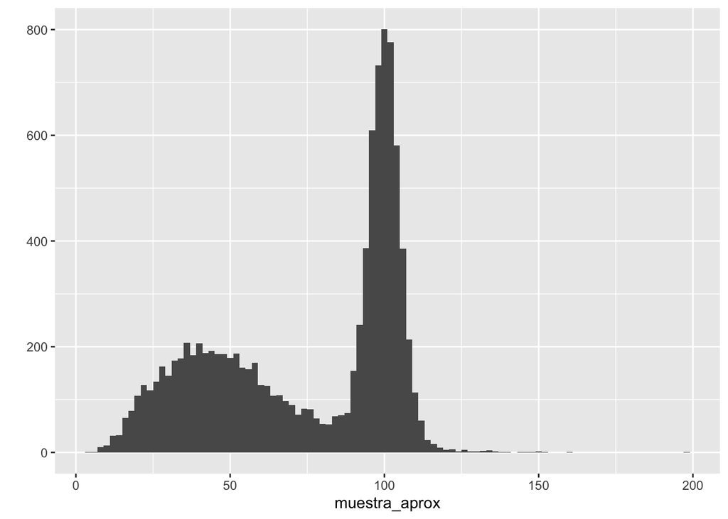

```r
muestra_aprox <- muestrear_pob(10000)
qplot(muestra_aprox, binwidth= 2)
```

Ahora consideramos estimar la media de esta distribución con un muestra de tamaño 50. ¿Cómo se ve la distribución de muestreo de la media? Grafica un histograma y una gráfica cuantil-cuantil normal.

## Trial 1: Naive one

Get bootsraped mean without control

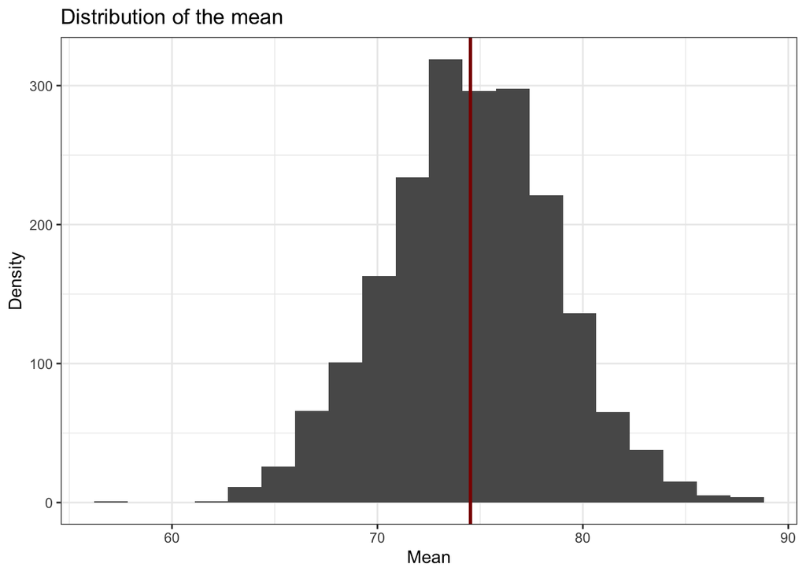

```r
M <- 50
medias <- map_dbl(1:2000,  ~ mean(sample(muestra_aprox, size=M, replace=TRUE)))

# plot
qplot(medias, bins=20) +
  geom_vline(xintercept = mean(medias), size = 1, color = "darkred") +
  xlab("Mean") + ylab("Density") +
  ggtitle("Distribution of the mean") +
  theme_bw()
```

# 3) SE($\bar{x}$)

3. **El error estándar de una media.** Supongamos que $x$ es una variable aleatoria que toma valores en los reales con distribución de probabilidad $F$. Denotamos por $\mu$ y $\sigma^2$ la media y varianza de $F$,

$$\mu = E(x),$$

$$\sigma^2=var(x)=E[(x-\mu)^2]$$

Ahora, sea $(X_1,...,X_n)$ una muestra aleatoria de $F$, de tamaño $n$, la media de la muestra $\bar{X}=\sum_{i=1}^nX_i/n$ tiene:

- esperanza $\mu$,
- varianza $\sigma^2/n$.

En palabras: la esperanza de $\bar{X}$ es la misma que la esperanza de $x$, pero la varianza de $\bar{X}$ es $1/n$ veces la varianza de $x$, así que entre mayor es la $n$ tenemos una mejor estimación de $\mu$.

En el caso del estimador de la media $\bar{X}$, el error estándar quedaría

$$ee(\bar{X}) = [var(\bar{X})]^{1/2}=
\sigma/ \sqrt{n}.$$
Entonces,

- Consideramos los datos de ENLACE edo. de México (ENLACE era una prueba estandarizada que se aplicaba a todos los alumnos de primaria en México), y la columna de calificaciones de español 3<sup>o</sup> de primaria (`esp_3`).

```r
df_enlace <- read_csv("../../data/enlace_15.csv")
df_enlace
```

```
## # A tibble: 7,518 × 8
##       id cve_ent turno    tipo     esp_3 esp_6 n_eval_3 n_eval_6
##    <dbl>   <dbl> <chr>    <chr>    <dbl> <dbl>    <dbl>    <dbl>
##  1 38570      15 MATUTINO INDêGENA   550   483       13       19
##  2 38571      15 MATUTINO INDêGENA   485   490       17       18
##  3 38572      15 MATUTINO INDêGENA   462   385        9        9
##  4 38573      15 MATUTINO INDêGENA   646   613       33       26
##  5 38574      15 MATUTINO INDêGENA   508   452       26       35
##  6 38575      15 MATUTINO INDêGENA   502   500       10       13
##  7 38576      15 MATUTINO INDêGENA   570   454       65       49
##  8 38577      15 MATUTINO INDêGENA   441   427       82       78
##  9 38578      15 MATUTINO INDêGENA   597   582      132      110
## 10 38579      15 MATUTINO INDêGENA   648   614       16       18
## # … with 7,508 more rows
```

- Genera un histograma de las calificaciones de 3<sup>o</sup> de primaria. Calcula la media y la desviación estándar.

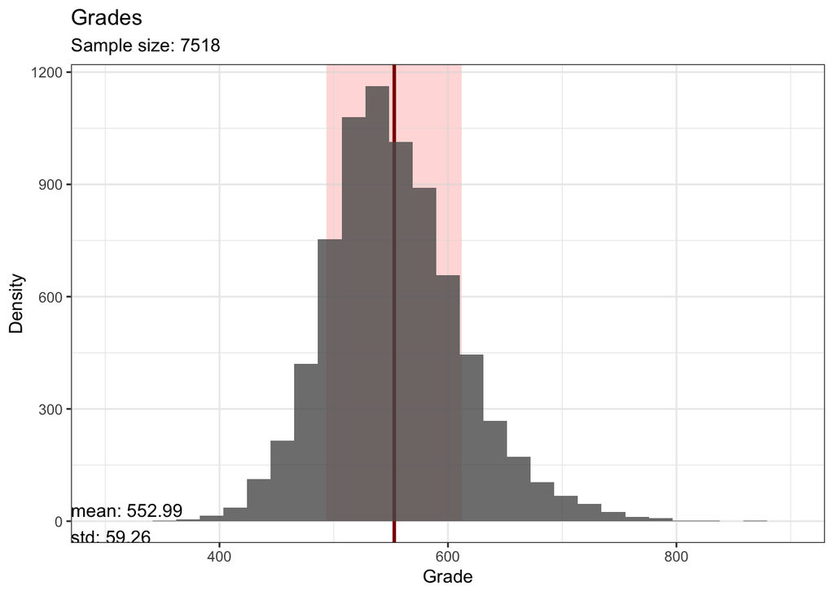

```r
plt_hist_grades <- function(df, M=-1){
  # size of the sample
  msize <- ifelse(M > 0, M, nrow(df))

  # subset df
  df <- df |> slice_sample(n = msize, replace = FALSE)

  # get mean and std
  mu <- mean(df$esp_3, na.rm = TRUE)
  sigma <- sd(df$esp_3, na.rm = TRUE)

  # plot
  print(
    df |>
      ggplot(aes(esp_3)) +
      geom_rect(aes(xmin = mu - sigma, xmax = mu + sigma, ymin = 0, ymax = Inf), fill = "pink", alpha = 0.01) +
      geom_vline(xintercept = mean(mu), size = 1, color = "darkred") +
      geom_histogram(alpha = 0.8, bins = 30) +
      ggtitle("Grades", str_glue("Sample size: {msize}")) +
      annotate("text", x=-Inf, y=-Inf, hjust=0, vjust=0, label=str_glue("mean: {round(mu, 2)} \nstd: {round(sigma, 2)}")) +
      xlab("Grade") + ylab("Density") +
      scale_x_continuous(limits = c(300, 900)) +
      theme_bw()
  )
}

plt_hist_grades(df_enlace)
```

We have the population mean & std which is

- $\mu = 552.99$
- $\sigma = 59.26$

## Histogram for different sample sizes

- Para tamaños de muestra $n = 10, 100, 1000$:

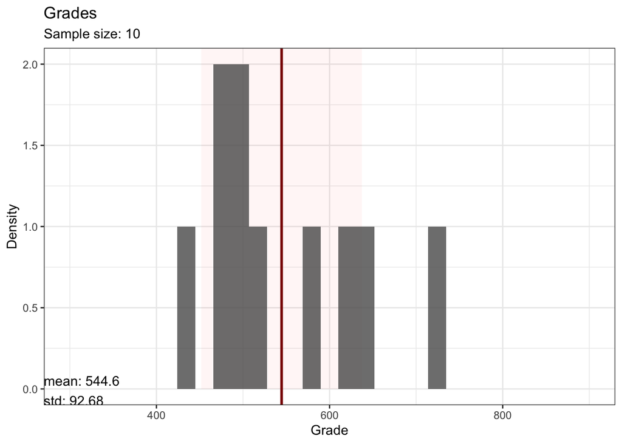

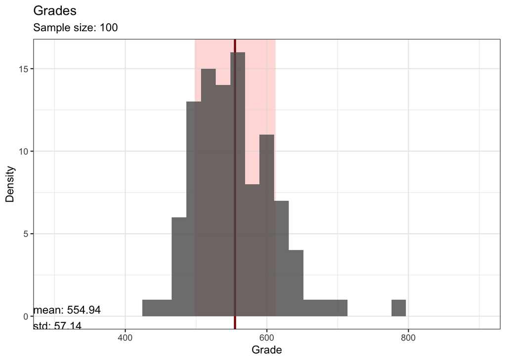

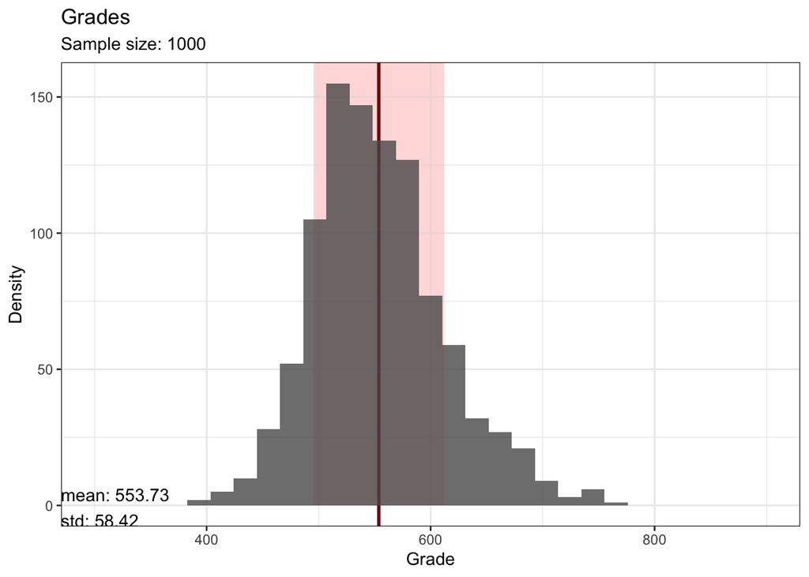

```r
for(num in c(10, 100, 1000))
  plt_hist_grades(df_enlace, num)
```

## bootstrap for different sample sizes

- Aproximareos la distribución muestral:
1. simula 5,000 muestras aleatorias (con reemplazo), ii) calcula la media en cada muestra, iii) Realiza un histograma de la distribución muestral de las medias (las medias del paso anterior) iv) aproxima el error estándar calculando la desviación estándar de las medias del paso ii.
- Calcula el error estándar de la media para cada tamaño de muestra usando la fórmula derivada arriba y compara con tus simulaciones.* **(doubt)**

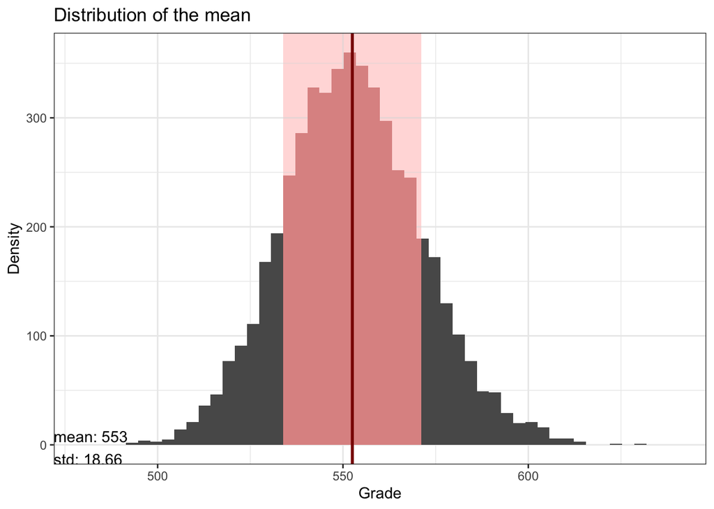

```
##
## bootstrapped sd 18.6594
```

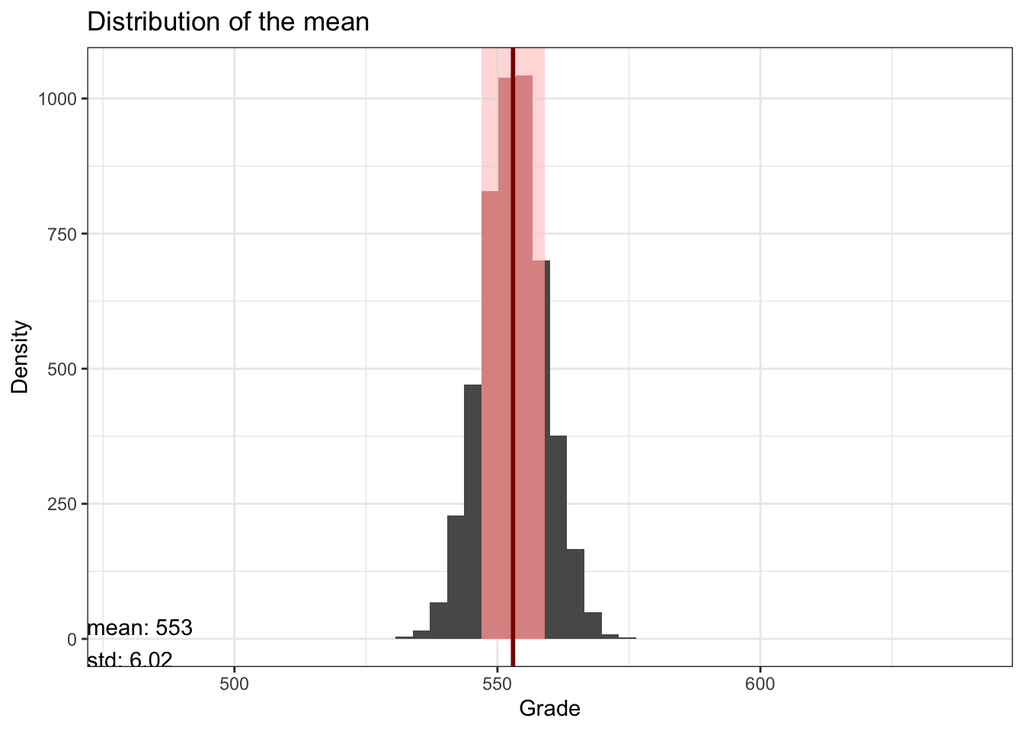

```
##
## bootstrapped sd 6.0242
```

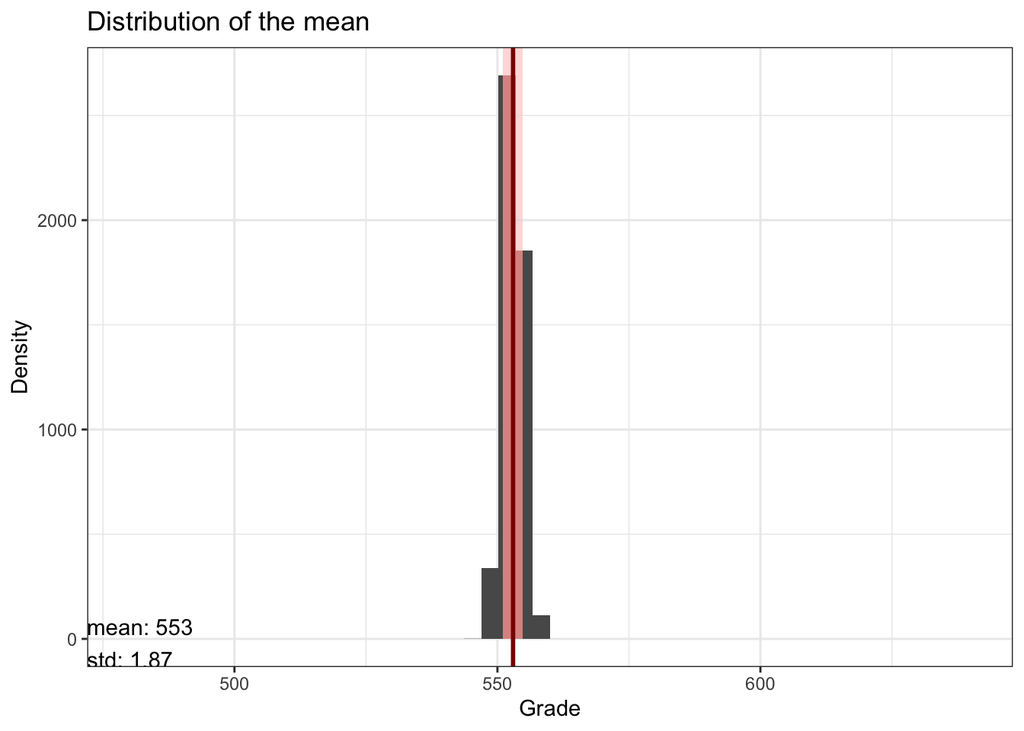

```
##
## bootstrapped sd 1.8695
```

```r
f_bootstrap_mean <- function(df, M, B){
  # B: number of simulations
  # M: size of the sample
  #g: statistical function

  # generate B samples of indexes
  b_samples <- lapply(1:B, function(x) sample(df$esp_3, size = M, replace = TRUE))

  # subset apply
  gsubset_apply <- function(x){
    return(mean(x))
  }

  # # get B samples of the stat
  stats <- sapply(b_samples, gsubset_apply)
  return(stats)
}

# simulation of the distribution
for(num in c(10, 100, 1000)){
  set.seed(8)
  boot_mean_grades <- f_bootstrap_mean(df_enlace, M=num, B=5000)

  # mean and std
  mean_grades <- mean(boot_mean_grades)
  sd_grades <- sd(boot_mean_grades)

  # plot
  print(qplot(boot_mean_grades, bins = 50) +
    geom_rect(aes(xmin = mean_grades - sd_grades, xmax = mean_grades + sd_grades, ymin = 0, ymax = Inf), fill = "pink", alpha = 0.01) +
    geom_vline(xintercept = mean_grades, size = 1, color = "darkred") +
    ggtitle("Distribution of the mean") +
    annotate("text", x=-Inf, y=-Inf, hjust=0, vjust=0, label=str_glue("mean: {round(mean_grades)} \nstd: {round(sd_grades, 2)}")) +
    xlab("Grade") + ylab("Density") +
    scale_x_continuous(limits = c(480, 640)) +
    theme_bw())

  # std
  cat("\n")
  cat(str_glue("\n bootstrapped sd {round(sd_grades, 4)}"))
}
```

```r
population_sd <- sqrt(sum((mean(df_enlace$esp_3) - df_enlace$esp_3)^2) / nrow(df_enlace))
cat("\n")
```

```r
cat(str_glue("population sd {round(population_sd, 4)}"))
```

```
## population sd 59.254
```

- ¿Cómo se comparan los errores estándar correspondientes a los distintos tamaños de muestra?

**ANSWER** It looks that for each $k$ in the 10^{k} increase of the sample reduces in $1/\sqrt n$ the mean std, as stated in $ee(\bar{X}) = [var(\bar{X})]^{1/2}= \sigma/ \sqrt{n}$.

```r
std_pop <- 59.26
cat(str_glue("population std: {std_pop}"))
```

```
## population std: 59.26
```

```r
cat("\n")
```

```r
cat(str_glue("theoretical decrease to 10: {std_pop/sqrt(10)}\n"))
```

```
## theoretical decrease to 10: 18.7396574141578
```

```r
cat("\n")
```

```r
cat(str_glue("theoretical decrease to 100: {std_pop/sqrt(100)}\n"))
```

```
## theoretical decrease to 100: 5.926
```

```r
cat("\n")
```

```r
cat(str_glue("theoretical decrease to 1000: {std_pop/sqrt(1000)}\n"))
```

```
## theoretical decrease to 1000: 1.87396574141578
```

```r
cat("\n")
```

For example, this implies that for a sample of ~1000 the $ee(\bar{X})$ will be approximately $\sigma/\sqrt{n} \approx 1.87$. So with simulations we can approach what should be the size of a sample in order to have a “sound” $ee(\bar{X})$.